# CARTILLA

## **Choque Cachi Vismark Abner** 2025-03-30

# LECTURA DE ARCHIVOS

## Leer csv

```r
#leer archivos
datos <- read.csv("C:/Users/Vismark Choque/Downloads/bmi.csv", header = TRUE, sep = ",", stringsAsFactors = FALSE)
```

**Parámetros principales**

.**`file`**: Ruta del archivo CSV. Puede ser una URL o un archivo local.  
.**`header`**: `TRUE` si la primera fila contiene nombres de columna.  
.**`sep`**: Separador de columnas (`","` por defecto, puede ser `";"` para archivos separados por punto y coma).  
.**`quote`**: Caracteres usados para encerrar texto (`"` por defecto).  
.**`dec`**: Separador decimal (`"."` por defecto, usar `","` para formatos europeos).  
.**`fill`**: `TRUE` rellena filas cortas con valores vacíos.  
.**`comment.char`**: Define un carácter para marcar comentarios (`""` desactiva comentarios).  
.**`stringsAsFactors`**: `FALSE` para leer texto como cadenas y no como factores.  
.**`encoding`**: Codificación del archivo (`"UTF-8"`, `"latin1"`, etc.).  
.**`na.strings`**: Especifica qué valores tratar como `NA`.  
.**`colClasses`**: Vector con los tipos de datos de las columnas.  
.**`nrows`**: Número de filas a leer (`-1` para leer todo el archivo).

## Leer XLSX

```r
# Instalar librerias
install.packages("readxl")
library(readxl)
# leer archivos
datos <- read_excel("nombre_archivo", sheet = 1, col_names = TRUE, skip = 0 )
```

**Parametros principales**

.**`path`**: Ruta del archivo Excel (puede ser una URL o un archivo local).  
.**`sheet`**: Puede ser el número de la hoja o el nombre de la hoja (por defecto es la primera hoja).  
.**`range`**: Un rango específico de celdas a leer (por ejemplo, `"A1:C10"`).  
.**`col_names`**: Si `TRUE`, usa la primera fila como nombres de columna.  
.**`col_types`**: Un vector que indica los tipos de columnas (por ejemplo, `"text"`, `"numeric"`, etc.).  
.**`na`**: Valores que se considerarán como `NA`.  
.**`skip`**: Número de filas a omitir al inicio del archivo.  
.**`n_max`**: Número máximo de filas a leer.  
.**`.name_repair`**: Método para manejar nombres duplicados de columnas (`"check_unique"` por defecto).

# VERIFICACION DE DATOS FALTANTES

```r
# Instalar librerias
install.packages("dplyr")   # Para manipulación de datos
# Importar librerias
library(dplyr)
```

```r
# Ver datos faltantes por columna
datos_faltantes<- colSums(is.na(datos))  # Suma de NA por columna
print(datos_faltantes)
```

```
##      Age   Height   Weight      Bmi BmiClass
##        0        0        0        0        0
```

## Visualizar datos faltantes en un grafico

```r
# Instalar librerias
if (!require(visdat)) {
  install.packages("visdat")
}
```

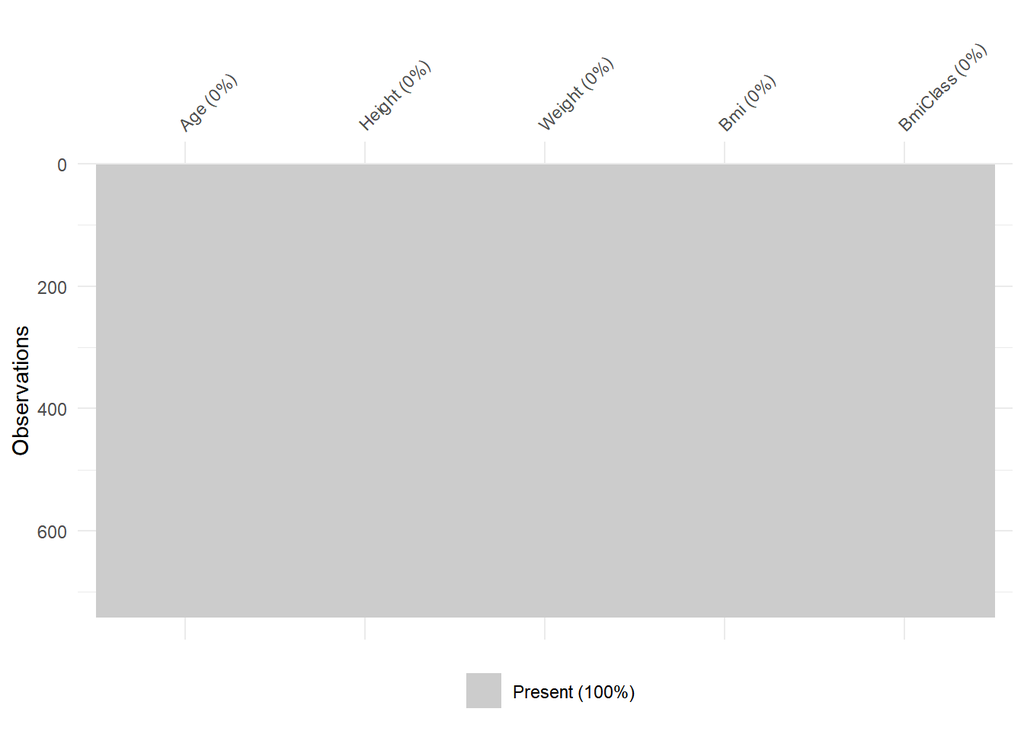

```r
# Importar librerias
library(visdat)
# Graficar
# Ver datos faltantes por columna
vis_miss(datos ,sort_miss = TRUE)
```

# IMPUTACION DE DATOS PARA SERIES DE TIEMPO

## METODO DE IMPUTACION GLOBAL

se refiere a la estrategia de **reemplazar los valores faltantes** en una serie temporal usando un **único valor** calculado a partir de toda la serie de datos, sin considerar la estructura temporal específica.

### MEDIA GLOBAL

Reemplazar los valores faltantes por la media de toda la serie temporal.

.**Ventaja**: Simple y rápido.

.**Desventaja**: No captura tendencias ni estacionalidades.

```r
# importar librerias
library(readxl)
datos_serie1 <- read_excel("C:/Users/Vismark Choque/Downloads/Tiquina.xlsx", sheet=2,skip=5)
head(datos_serie1)
```

| AÑO | MES / DIA | 1.0 | 2.0 | 3.0 | 4.0 | 5.0 | 6.0 | 7.0 | 8.0 | 9.0 | 10.0 | 11.0 | 12.0 | 13.0 | 14.0 | 15.0 | 16.0 | 17.0 | 18.0 | 19.0 | 20.0 | 21.0 | 22.0 | 23.0 | 24.0 | 25.0 | 26.0 | 27.0 | 28.0 | … |
| --- | --- | --- | --- | --- | --- | --- | --- | --- | --- | --- | --- | --- | --- | --- | --- | --- | --- | --- | --- | --- | --- | --- | --- | --- | --- | --- | --- | --- | --- | --- |
| 1957 | 6 | 12 | 2 | 17.0 | 17.0 | 17 | 7 | 7.0 | 7 | 8.0 | 12 | 18.0 | 14.0 | 8 | 8.0 | 6 | 6 | 10.0 | 13 | 13.0 | 9 | 8.0 | 7 | 10.0 | 11.0 | 12.0 | 12.0 | 7 | NA | … |
| 1957 | 7 | NA | 6 | 12.0 | 5.0 | 5 | 5 | 6.0 | 6 | 16.0 | 7 | 6.0 | 7.0 | 9 | 10.0 | 8 | 10 | 10.0 | 9 | 10.0 | 8 | 7.0 | 5 | 8.0 | 8.0 | 7.0 | 8.0 | 9 | 8.0 | … |
| 1957 | 10 | 11 | 14 | 20.5 | 16.0 | 17 | 15 | 12.5 | 12 | 12.0 | 12 | 12.5 | 17.5 | 17 | 18.0 | 14 | 15 | 12.0 | 14 | 10.0 | 14 | 12.0 | 11 | 19.0 | 11.5 | 13.0 | 12.0 | 13 | 13.5 | … |
| 1957 | 11 | 14 | 13 | 11.0 | 12.0 | 11 | 12 | 13.0 | 13 | 21.3 | 11 | 14.0 | 13.0 | 14 | 13.5 | 11 | 12 | 9.5 | 7 | 12.5 | 13 | 12.0 | 9 | 13.0 | 18.0 | 13.5 | 14.0 | 13 | 13.0 | … |
| 1957 | 12 | 12 | 13 | 14.0 | 11.5 | 15 | 20 | 13.0 | 12 | 14.0 | 13 | 14.0 | 14.0 | 15 | 17.0 | 16 | 14 | 12.0 | 11 | 13.0 | 12 | 13.0 | 14 | 11.5 | 11.5 | 17.0 | 19.5 | 19 | 19.0 | … |
| 1958 | 1 | 18 | 19 | 19.0 | 21.0 | 20 | 19 | 19.0 | 20 | 20.0 | 19 | 20.0 | 21.0 | 20 | 19.0 | 20 | 19 | 22.0 | 18 | 19.0 | 20 | 18.5 | 19 | 21.0 | 20.0 | 20.0 | 21.0 | 22 | 19.0 | … |

Ver si existe datos faltantes

```r
library(visdat)
datos_faltantes_serie <- colSums(is.na(datos_serie1))
print(datos_faltantes_serie)
```

```
##       AÑO MES / DIA       1.0       2.0       3.0       4.0       5.0       6.0       7.0       8.0       9.0      10.0      11.0
##         0         0         4         2         5         5         0         0         1         0         1         0         0
##      12.0      13.0      14.0      15.0      16.0      17.0      18.0      19.0      20.0      21.0      22.0      23.0      24.0
##         0         0         0         0         0         0         0         2         5         1         1         0         0
##      25.0      26.0      27.0      28.0      29.0      30.0      31.0
##         0         0         0         1        10        13        50
```

Tenemos datos faltantes Entonces lo primero que se hara es convertir nuestra tabla de un formato corto a un formato largo

```r
# Instalar librerias
if (!require(tidyr)) {
  install.packages("tidyr")
}
# Importar librerias
library(tidyr)
library(dplyr)
#Convertir a formato largo
datos_largos<- datos_serie1 %>%
  pivot_longer(cols = starts_with("1"):starts_with("31"),
               names_to = "DIA",
               values_to = "VALOR") %>%
  mutate(AÑO = as.integer(AÑO))
```

# GRAFICOS

## GRAFICOS DATOS CONTINUOS

### HISTOGRAMA

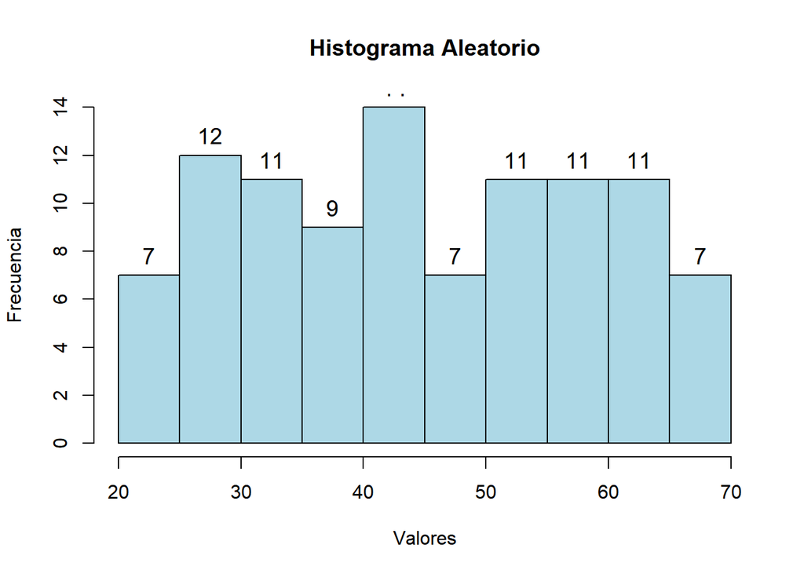

```r
set.seed(123)

data("mtcards")

data <- runif(100, min = 20, max = 70)

# Crear histograma
hist_data <- hist(data, main="Histograma Aleatorio", col="lightblue", border="black", xlab="Valores", ylab="Frecuencia")

# Agregar etiquetas con las frecuencias
text(hist_data$mids, hist_data$counts, labels=hist_data$counts, pos=3, col="black", cex=1.2)
```

### Boxplot

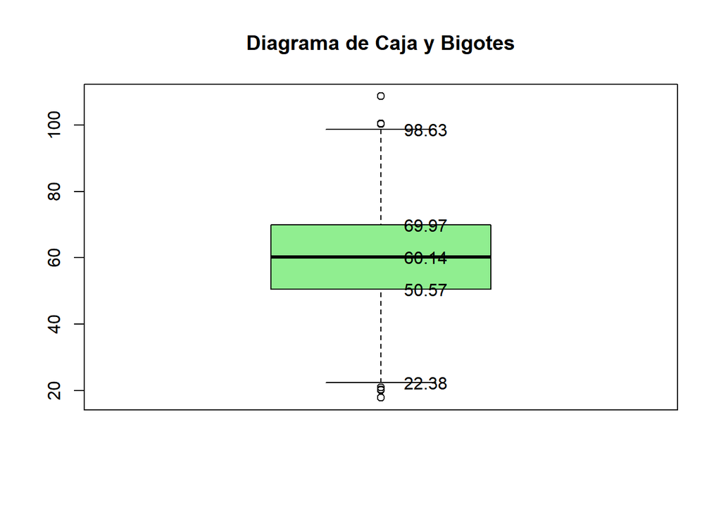

```r
set.seed(123)

# Generar datos
data_box <- rnorm(1000, mean = 60, sd = 15)

# Crear boxplot y guardar estadísticas
box <- boxplot(data_box, main="Diagrama de Caja y Bigotes", col="lightgreen")

# Agregar etiquetas numéricas en los bigotes y la mediana
text(1.2, box$stats, labels = round(box$stats, 2), col="black", cex=1,2)
```

### BARRAS APILADAS

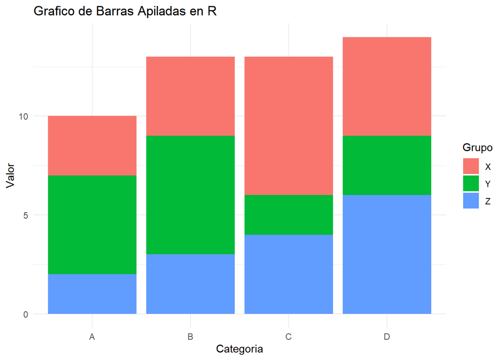

```r
library(ggplot2)

# Datos de ejemplo
datos <- data.frame(
  Categoria = rep(c("A", "B", "C", "D"), each = 3),
  Grupo = rep(c("X", "Y", "Z"), times = 4),
  Valor = c(3, 5, 2, 4, 6, 3, 7, 2, 4, 5, 3, 6)
)

# Crear el gráfico de barras apiladas
ggplot(datos, aes(x = Categoria, y = Valor, fill = Grupo)) +
  geom_bar(stat = "identity") +
  labs(title = "Grafico de Barras Apiladas en R",
       x = "Categoria",
       y = "Valor",
       fill = "Grupo") +
  theme_minimal()
```

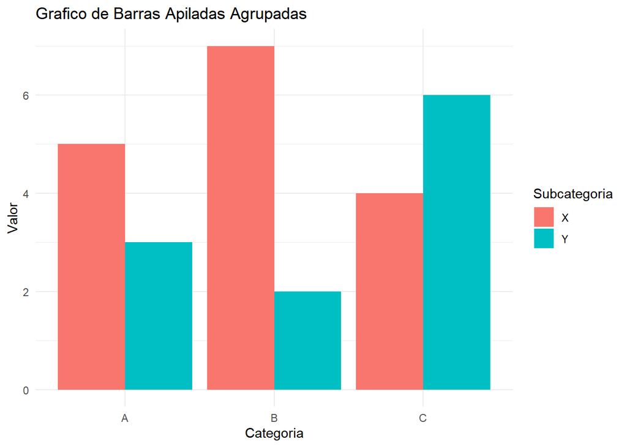

```r
# Cargar la librería
library(ggplot2)

# Crear un dataframe de ejemplo
data <- data.frame(
  Categoria = rep(c("A", "B", "C"), each = 2),
  Subcategoria = rep(c("X", "Y"), times = 3),
  Valor = c(5, 3, 7, 2, 4, 6)
)

# Crear el gráfico de barras apiladas agrupadas
ggplot(data, aes(x = Categoria, y = Valor, fill = Subcategoria)) +
  geom_bar(stat = "identity", position = "dodge") +  # Cambiar a "dodge" para barras agrupadas
  theme_minimal() +
  labs(title = "Grafico de Barras Apiladas Agrupadas", x = "Categoria", y = "Valor")
```

### GRAFICO DE LINEAS

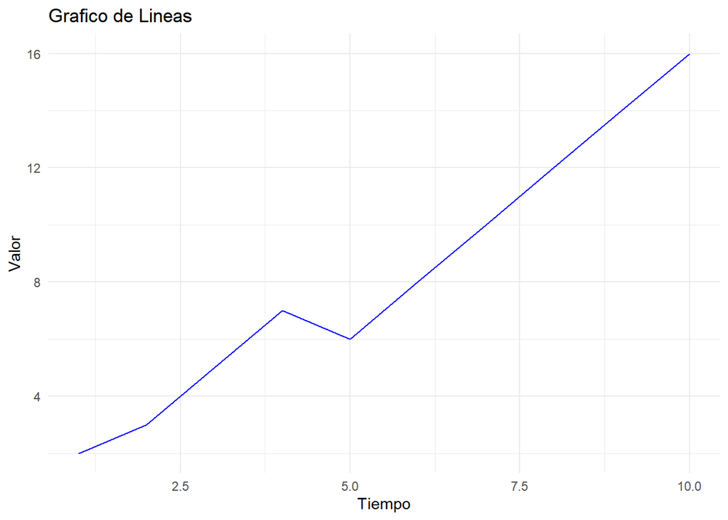

```r
# Cargar la librería ggplot2
library(ggplot2)

# Crear un dataframe de ejemplo
data <- data.frame(
  tiempo = 1:10,           # Eje X (tiempo)
  valor = c(2, 3, 5, 7, 6, 8, 10, 12, 14, 16)  # Eje Y (valor)
)

# Crear el gráfico de líneas
ggplot(data, aes(x = tiempo, y = valor)) +
  geom_line(color = "blue") +    # Usar geom_line() para el gráfico de líneas
  theme_minimal() +              # Usar tema minimalista
  labs(title = "Grafico de Lineas", x = "Tiempo", y = "Valor")  # Títulos y etiquetas
```

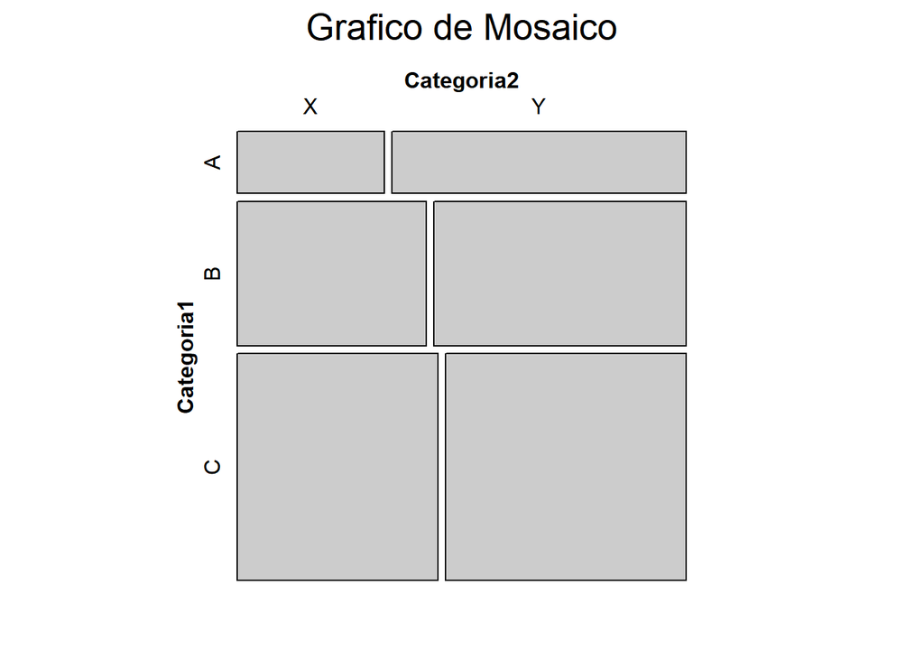

```r
# Cargar la librería ggplot2
# Cargar la librería vcd
library(vcd)

# Crear un dataframe de ejemplo
data <- data.frame(
  Categoria1 = c("A", "A", "B", "B", "C", "C"),
  Categoria2 = c("X", "Y", "X", "Y", "X", "Y"),
  Frecuencia = c(10, 20, 30, 40, 50, 60)
)

# Crear una tabla de contingencia
tabla <- xtabs(Frecuencia ~ Categoria1 + Categoria2, data = data)

# Crear el gráfico de mosaico
mosaic(tabla,
       main = "Grafico de Mosaico",
       color = c("skyblue", "lightgreen"),
       labeling_args = list(set_varnames = c("Categoria1", "Categoria2")))
```

### MAPA DE CALOR

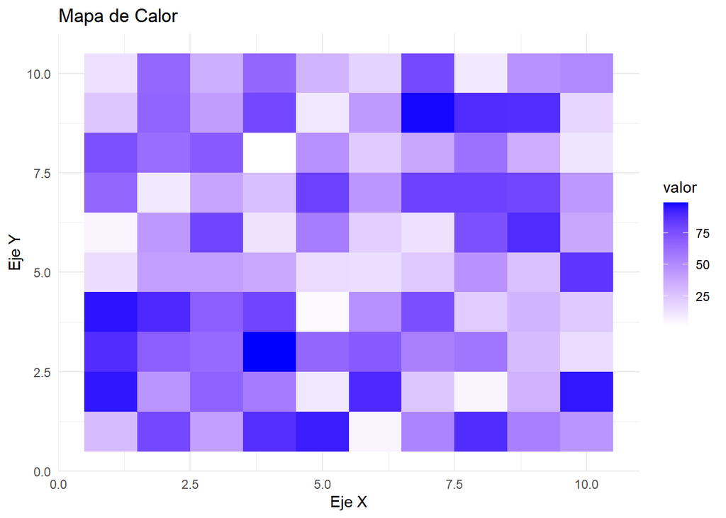

```r
# Cargar la librería ggplot2
library(ggplot2)

# Crear un dataframe de ejemplo
set.seed(123)  # Establecer semilla para reproducibilidad
data <- expand.grid(x = 1:10, y = 1:10)  # Crear una cuadrícula de 10x10
data$valor <- runif(100, min = 1, max = 100)  # Asignar valores aleatorios a la cuadrícula

# Crear el mapa de calor
ggplot(data, aes(x = x, y = y, fill = valor)) +
  geom_tile() +  # Usar geom_tile() para crear el mapa de calor
  scale_fill_gradient(low = "white", high = "blue") +  # Establecer el gradiente de colores
  theme_minimal() +  # Usar tema minimalista
  labs(title = "Mapa de Calor", x = "Eje X", y = "Eje Y")  # Títulos y etiquetas
```

### GRAFICO DE BURBUJAS

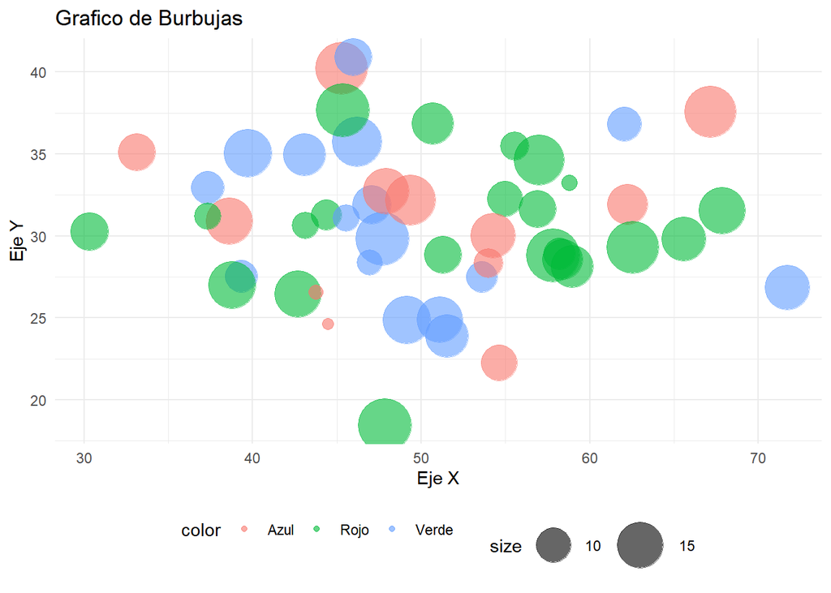

```r
# Cargar la librería ggplot2
library(ggplot2)

# Crear un dataframe de ejemplo
set.seed(123)
data <- data.frame(
  x = rnorm(50, mean = 50, sd = 10),  # Valores aleatorios para el eje X
  y = rnorm(50, mean = 30, sd = 5),   # Valores aleatorios para el eje Y
  size = runif(50, min = 5, max = 20), # Valores aleatorios para el tamaño de las burbujas
  color = sample(c("Rojo", "Verde", "Azul"), 50, replace = TRUE)  # Color de las burbujas
)

# Crear el gráfico de burbujas
ggplot(data, aes(x = x, y = y, size = size, color = color)) +
  geom_point(alpha = 0.6) +  # Usar geom_point() para las burbujas
  scale_size_continuous(range = c(3, 15)) +  # Ajustar el rango del tamaño de las burbujas
  labs(title = "Grafico de Burbujas", x = "Eje X", y = "Eje Y") +
  theme_minimal() +
  theme(legend.position = "bottom")  # Mover la leyenda a la parte inferior
```

### GRAFICO DE FLUJO CON AREAS APILADAS

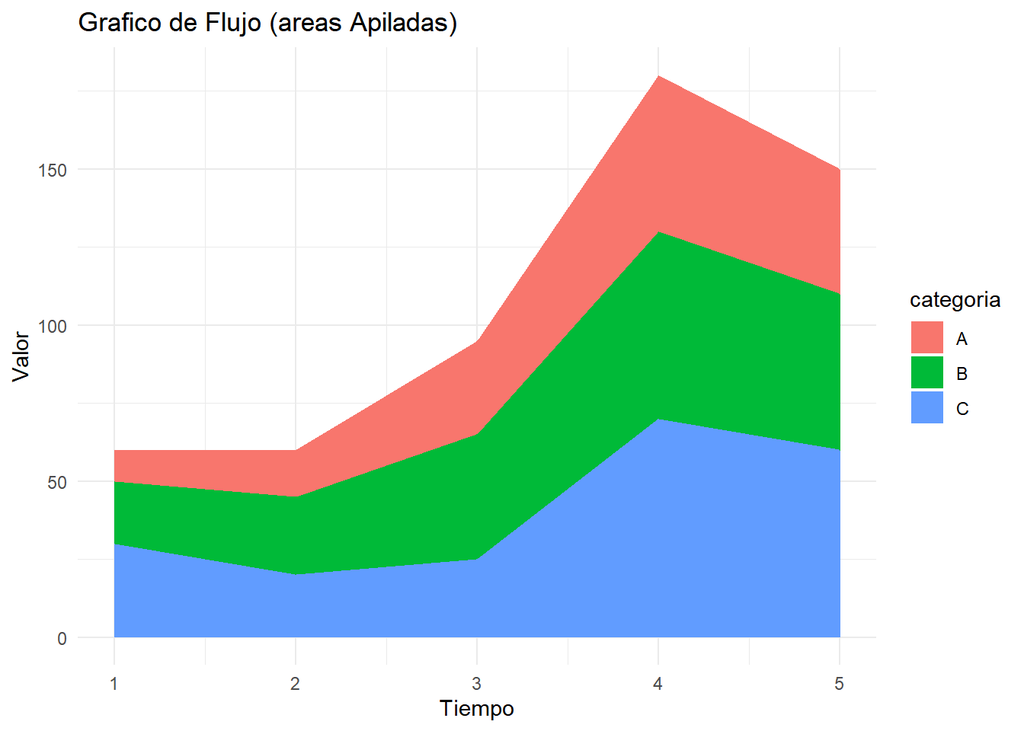

```r
# Cargar la librería ggplot2
library(ggplot2)

# Crear un dataframe de ejemplo
data <- data.frame(
  tiempo = rep(1:5, each = 3),
  categoria = rep(c("A", "B", "C"), times = 5),
  valor = c(10, 20, 30, 15, 25, 20, 30, 40, 25, 50, 60, 70, 40, 50, 60)
)

# Crear un gráfico de flujo (áreas apiladas)
ggplot(data, aes(x = tiempo, y = valor, fill = categoria)) +
  geom_area(position = "stack") +  # Apilar las áreas
  labs(title = "Grafico de Flujo (areas Apiladas)", x = "Tiempo", y = "Valor") +
  theme_minimal()
```